# Comparación de Pacientes en Cirugía de Implantes Dentales: Colocación vs. Periimplantaria

Grupo Proyecto 3

2024-04-18

# INTRODUCCIÓN

Este análisis compara las **características de pacientes sometidos a cirugía de colocación de implantes en la unidad de Implantología Bucal** con aquellos tratados en la **Unidad de Mantenimiento de Implantes**. El **objetivo** es **identificar factores de riesgo para complicacione**s en implantes dentales, **mejorando** así la **atención clínica** y la selección de pacientes.

# CARGA Y LIMPIEZA DE DATOS

## Carga

```r
# Cargamos los datos
data = read.csv('combianted_Total.csv')

#Visualizamos los tipos de cirugia
unique(data$Tipo_De_Intervencion_Quirurgica)
```

```
## [1] "Cirugia Dentoalveolar"     "0"
## [3] "Implantologia Bucal"       "CirugÃa Peri-implantaria"
```

En odontología, tenemos tres tipos principales de intervenciones quirúrgicas:

1. *Cirugía Dentoalveolar*: Tratamiento de enfermedades y afecciones dentales y de los tejidos circundantes.
2. *Implantología Bucal*: Colocación de implantes dentales para reemplazar dientes perdidos.
3. *Cirugía Peri-implantaria*: Tratamiento de afecciones alrededor de los implantes dentales.

Nos centraremos en las intervenciones de **Implantología Bucal** y **Cirugía Peri-implantaria** para este estudio.

##Prueba AFC Vamos a intentar quedarnos con las características de los dos tipos de operación, creando variables cualitativas (tipo de medicamento actual, género, consumo alcohol, tabaco… y tipo de patología sistemática) para poder explicar a través de un AFC si pertenecen al segundo tipo o al tercer tipo.

```r
library(dplyr)
data <- data %>%
  filter(data$Tipo_De_Intervencion_Quirurgica == "Implantologia Bucal" | data$Tipo_De_Intervencion_Quirurgica == "CirugÃa Peri-implantaria" )
data <- data[, 1:111]
conteo <- table(data$Tipo_De_Intervencion_Quirurgica)
print(conteo)
```

```
##
## CirugÃa Peri-implantaria       Implantologia Bucal
##                        32                        98
```

```r
#creamos columna del tipo de patología
for(i in 17:57) {
  # Accedemos al nombre de la columna i-ésima
  col_name <- names(data)[i]

  # Usamos un bucle para revisar cada fila
  for(j in 1:nrow(data)) {
    # Si encontramos un 1 en la columna i-ésima de la fila j-ésima
    if(data[j, i] == 1) {
      # Actualizamos 'Patologia_1stemica' con el nombre de la columna actual
      data[j, 'Patologia_1stemica'] <- col_name
    }
  }
}
data <- data %>%
  mutate(Patologia_1stemica = replace(Patologia_1stemica, Patologia_1stemica == "0", "ninguna"))






#creamos una columna del tipo de medicación
for(i in 60:108) {
  # Accedemos al nombre de la columna i-ésima
  col_name <- names(data)[i]

  # Usamos un bucle para revisar cada fila
  for(j in 1:nrow(data)) {
    # Si encontramos un 1 en la columna i-ésima de la fila j-ésima
    if(data[j, i] == 1) {
      # Actualizamos 'Patologia_1stemica' con el nombre de la columna actual
      data[j, 'Medicacion_Actual2'] <- col_name
    }
  }
}
data <- data %>%
  mutate(Medicacion_Actual2 = replace(Medicacion_Actual2, Medicacion_Actual2 == "0", "ninguna"))


data <- data %>%
  select(-c(17:57, 60:108))

conteo <- table(data$Tipo_De_Intervencion_Quirurgica)
print(conteo)
```

```
##
## CirugÃa Peri-implantaria       Implantologia Bucal
##                        32                        98
```

```r
#install.packages('lubridate')
library(lubridate)
library(dplyr)

# Primero, ajustamos los años en la fecha de nacimiento
data$Fecha_Nacimiento <- as.character(data$Fecha_Nacimiento)

data$Fecha_Nacimiento <- sapply(data$Fecha_Nacimiento, function(fecha) {
  partes <- strsplit(fecha, "/")[[1]]
  año <- as.numeric(partes[3])
  if (año > 20 && año <= 99) {  # Si el año está entre 21 y 99, se considera siglo XX
    partes[3] <- paste0("19", partes[3])
  } else if (año <= 20) {  # Si el año es 20 o menor, se considera siglo XXI
    partes[3] <- paste0("20", partes[3])
  }
  paste(partes[1], partes[2], partes[3], sep = "/")
})

data$Fecha_Nacimiento <- dmy(data$Fecha_Nacimiento)

# Ahora calculamos la edad
data$edad <- floor(interval(start = data$Fecha_Nacimiento, end = Sys.Date()) / years(1))

# Finalmente, creamos la columna 'categoria_edad' con las categorías especificadas
data <- data %>%
  mutate(categoria_edad = case_when(
    edad >= 10 & edad < 20 ~ '10-20',
    edad >= 20 & edad < 30 ~ '20-30',
    edad >= 30 & edad < 40 ~ '30-40',
    edad >= 40 & edad < 50 ~ '40-50',
    edad >= 50 & edad < 60 ~ '50-60',
    edad >= 60 & edad < 70 ~ '60-70',
    edad >= 70 & edad < 80 ~ '70-80',
    edad >= 80 & edad < 90 ~ '80-90',
    edad >= 90 & edad <= 100 ~ '90-100',
    TRUE ~ 'Fuera de rango'
  ))
conteo <- table(data$Tipo_De_Intervencion_Quirurgica)
print(conteo)
```

```
##
## CirugÃa Peri-implantaria       Implantologia Bucal
##                        32                        98
```

```r
#creamos variable nivel de fumador categorico
data <- data %>%
  mutate(nivel_de_fumador = case_when(
    `Fumador.a` == 1 ~ "Fumador.a",
    `No.fumador.a` == 1 & `Exfumador.a` == 1 ~ "Exfumador.a",
    `Exfumador.a` == 1 & `No.fumador.a` == 0 ~ "Exfumador.a",
    `No.fumador.a` == 1 & `Exfumador.a` == 0 ~ "No.fumador.a",
    TRUE ~ NA_character_  # Para cualquier otro caso no especificado, asignamos NA
  ))


#eliminamos las que hemos transformado (agrupado en una columna)

data <- data %>%
  select(-Fecha_Nacimiento, -Date_Create, -IP_Adress, -Operador, -Auxiliar, -Jefe_de_dia, -Fecha_intervencion, -Fecha_Nacimiento, -No.fumador.a, -Exfumador.a, -Fumador.a, -Otras_Drogas, -Medicacion_actual, -Otro..especifique., -edad, -Tipo_De_cirugia, -Otro..especifique._17)

data <- data %>%
  select(-NÃºmero_de_cigarrillos.dÃ.a)
data <- data[!is.na(data$nivel_de_fumador), ]

conteo <- table(data$Tipo_De_Intervencion_Quirurgica)
print(conteo)
```

```
##
## CirugÃa Peri-implantaria       Implantologia Bucal
##                        29                        93
```

```r
head(data)
```

```
##   Genero     Patologia_1stemica          Alcohol        Medicacion_Actual2
## 1 Hombre                ninguna Consumo Moderado                   ninguna
## 2  Mujer   Infarto.de.Miocardio       No consumo FÃ.rmacos.hipolipemiantes
## 3  Mujer                ninguna Consumo Moderado                   ninguna
## 4 Hombre                ninguna Consumo Moderado                   ninguna
## 5 Hombre HipertensiÃ³n.Arterial       No consumo         Antihipertensivos
## 6 Hombre                ninguna       No consumo                   ninguna
##   Tipo_De_Intervencion_Quirurgica categoria_edad nivel_de_fumador
## 1             Implantologia Bucal          30-40     No.fumador.a
## 2             Implantologia Bucal          60-70     No.fumador.a
## 3             Implantologia Bucal          40-50     No.fumador.a
## 4             Implantologia Bucal          50-60     No.fumador.a
## 5             Implantologia Bucal          60-70     No.fumador.a
## 6             Implantologia Bucal          60-70     No.fumador.a
```

COmo patologia sistematica y medicacion actual contienen muchos valores con pocas muestras vamos a poner que se agrupen los que salgan menos de x veces en un valor llamado otros (así pasamos de explicar el 6% de la variabilidad al 12%) :

```r
#install.packages('estimability')
#install.packages('FactoMineR')
#install.packages('factoextra')
library(estimability)
library(FactoMineR)
library(factoextra)
# Obtener la frecuencia de cada valor en Patologia_1stemica
freq_patologia <- table(data$Patologia_1stemica)

# Mostrar los valores que aparecen menos de 5 veces
print(freq_patologia[freq_patologia < 5])
```

```
##
##                       1                Artritis                    Asma
##                       3                       3                       2
##              DepresiÃ³n              Diabetes.I             Diabetes.II
##                       3                       1                       3
##                    Gota               Hepatitis         Hipertiroidismo
##                       2                       4                       1
##   HipotensiÃ³n.Arterial          Hipotiroidismo    Infarto.de.Miocardio
##                       1                       1                       1
## Insuficiencia.CardÃ.aca            Osteoporosis                     VIH
##                       1                       1                       1
```

```r
# Identificar los valores que aparecen menos de 5 veces
infrequent_values <- names(freq_patologia[freq_patologia < 5])

# Actualizar los valores a 'Otros'
data$Patologia_1stemica[data$Patologia_1stemica %in% infrequent_values] <- 'Otros'

# Verificar los cambios
table(data$Patologia_1stemica)
```

```
##
##               Artrosis    Hipercolesterolemia HipertensiÃ³n.Arterial
##                      5                     16                      5
##                ninguna                  Otros
##                     68                     28
```

```r
#y hacemos lo mismo con medicacion actual
# Obtener la frecuencia de cada valor en Patologia_1stemica
freq_medicacion <- table(data$Medicacion_Actual2)

# Mostrar los valores que aparecen menos de 5 veces
print(freq_medicacion[freq_medicacion < 2])
```

```
##
##                AnalgÃ.sicos               AnsiolÃ.ticos
##                           1                           1
## Antiagregantes.plaquetarios           Antirretrovirales
##                           1                           1
##           Broncodilatadores                 DiurÃ.ticos
##                           1                           1
##               Expectorantes
##                           1
```

```r
# Identificar los valores que aparecen menos de 5 veces
infrequent_values <- names(freq_medicacion[freq_medicacion < 5])

# Actualizar los valores a 'Otros'
data$Medicacion_Actual2[data$Medicacion_Actual2 %in% infrequent_values] <- 'Otros'

# Verificar los cambios
table(data$Medicacion_Actual2)
```

```
##
##                         1            Antidepresivos         Antihipertensivos
##                         6                         8                        10
## FÃ.rmacos.hipolipemiantes                   ninguna                     Otros
##                        11                        71                        16
```

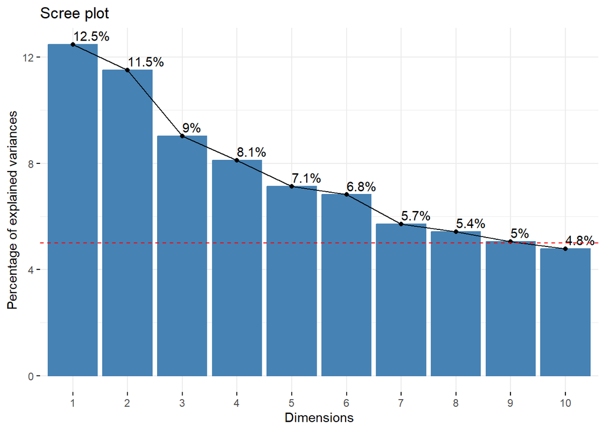

```r
dataCAT = data



res.mca2 <- MCA(data, graph = FALSE, quali.sup = 1)
eig.val2 <- get_eigenvalue(res.mca2)
VPmedio2 = 100 * (1/nrow(eig.val2))
fviz_eig(res.mca2, addlabels = TRUE) + geom_hline(yintercept=VPmedio2, linetype=2, color="red")
```

Vemos si separan los individuos

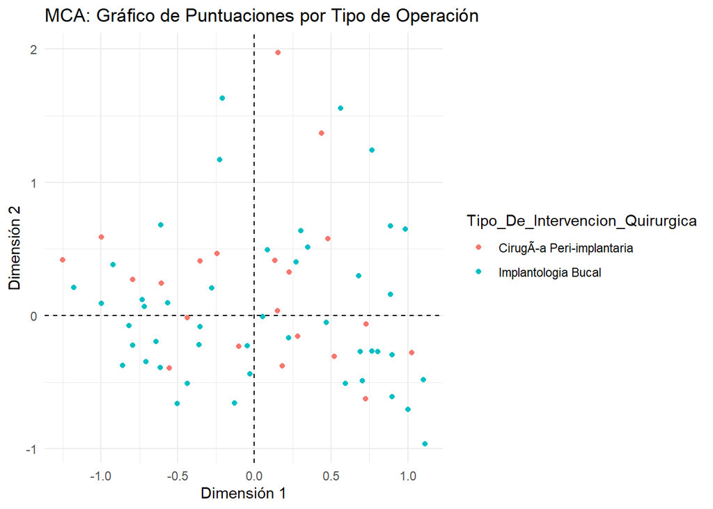

```r
# Instalar devtools si aún no lo has hecho

library(FactoMineR)
library(factoextra)

library(ggplot2)
library(factoextra)

# Asumiendo que res.mca2 es tu resultado de MCA
# Extraemos manualmente las coordenadas de los individuos desde el resultado del MCA
ind.coords <- as.data.frame(res.mca2$ind$coord)

# Añadimos la variable 'tipo_de_operacion' al data.frame de coordenadas
# Asegúrate de que la longitud de 'datos$tipo_de_operacion' y 'ind.coords' coinciden
ind.coords$Tipo_De_Intervencion_Quirurgica <- data$Tipo_De_Intervencion_Quirurgica


names(ind.coords) <- gsub(" ", ".", names(ind.coords))
# Ahora que tenemos un data.frame con las coordenadas y el tipo de operación, podemos proceder a graficar
ggplot(ind.coords, aes(x = Dim.1, y = Dim.2, color = Tipo_De_Intervencion_Quirurgica)) +
  geom_point() +
  theme_minimal() +
  labs(x = "Dimensión 1", y = "Dimensión 2", title = "MCA: Gráfico de Puntuaciones por Tipo de Operación", color = "Tipo_De_Intervencion_Quirurgica") +
  geom_hline(yintercept = 0, linetype = "dashed") +
  geom_vline(xintercept = 0, linetype = "dashed")
```

Contribuciones variables

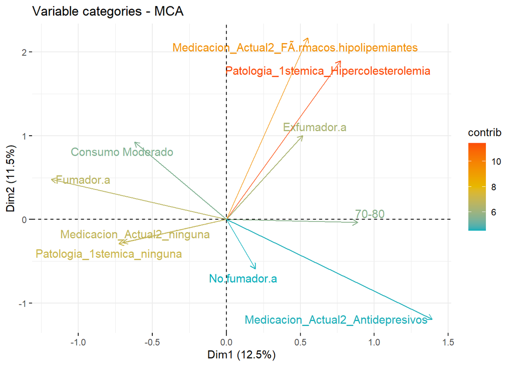

```r
plot_var_contrib_pca <- fviz_pca_var(res.mca2,
                                     select.var = list(contrib = 10), # Selecciona variables que contribuyen al menos un 10%
                                     col.var = "contrib", # Color de las variables basado en su contribución
                                     gradient.cols = c("#00AFBB", "#E7B800", "#FC4E07"), # Colores del gradiente
                                     repel = TRUE) # Evitar solapamiento de etiquetas

# Mostrar el gráfico
print(plot_var_contrib_pca)
```

## PCA para ver si se separa

Volvemos a cargar los datos porque ahora los queremos numéricos

```r
library(factoextra)
library(cluster)
library(gridExtra)
data = read.csv('combianted_Total.csv')
data <- data[, 1:111]


#convertimos la variable genero a binario:
data <- data %>%
  mutate(Genero = case_when(
    Genero == "Mujer" ~ "1",
    Genero == "Hombre" ~ "0",
    Genero == "0" ~ NA_character_, # Convertimos el "0" string a NA
    TRUE ~ Genero # Mantener el valor original en otros casos (si los hay)
  )) %>%
  mutate(Genero = as.numeric(Genero)) # Convertir a numérico para tener 1, 0 y NA

data <- data %>%
  filter(!is.na(Genero))

data <- data %>% filter(data$Tipo_De_Intervencion_Quirurgica == "Implantologia Bucal" | data$Tipo_De_Intervencion_Quirurgica == "CirugÃa Peri-implantaria" )

tipo_intervencion <- data$Tipo_De_Intervencion_Quirurgica
data <- select(data,-IP_Adress, -Operador, -Auxiliar, -Jefe_de_dia, -Fumador.a, -Medicacion_actual, -NÃºmero_de_cigarrillos.dÃ.a)
dataPCA = data

dataPCA_comparativo <- data %>%
  select_if(is.numeric)
```

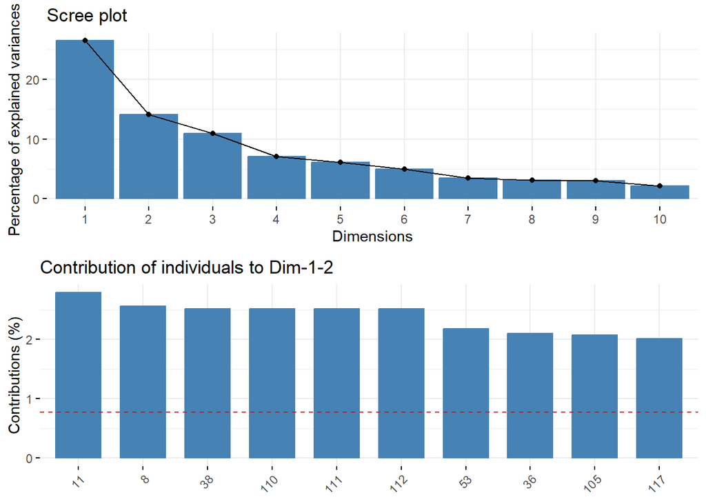

```r
# Realizar el análisis de componentes principales (PCA)
pca_result <- prcomp(dataPCA_comparativo)

# Gráfico de la varianza explicada por cada componente principal
plot_eigenvalues <- fviz_eig(pca_result)

# Gráfico de las contribuciones de las variables a los ejes principales
plot_var_contrib <- fviz_contrib(pca_result, choice = "var", axes = 1:2, top = 10)

# Gráfico de las contribuciones de los individuos a los ejes principales
plot_ind_contrib <- fviz_contrib(pca_result, choice = "ind", axes = 1:2, top = 10)

# Organizar los gráficos en una cuadrícula
grid.arrange(plot_eigenvalues, plot_ind_contrib,
             ncol = 1)
```

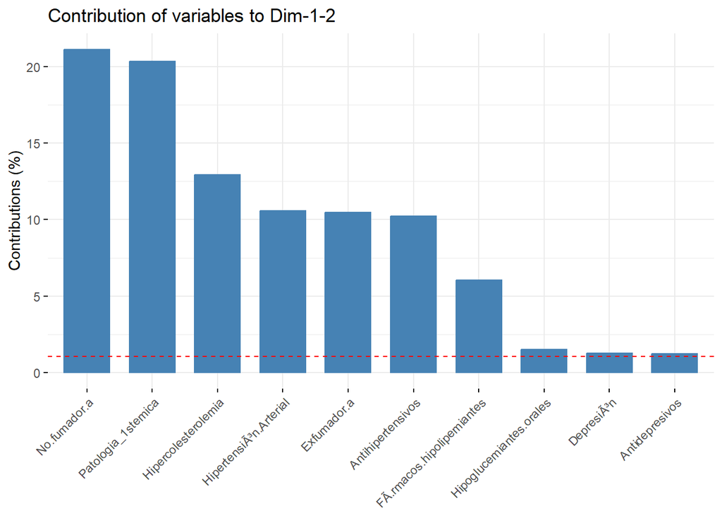

```r
plot_var_contrib
```

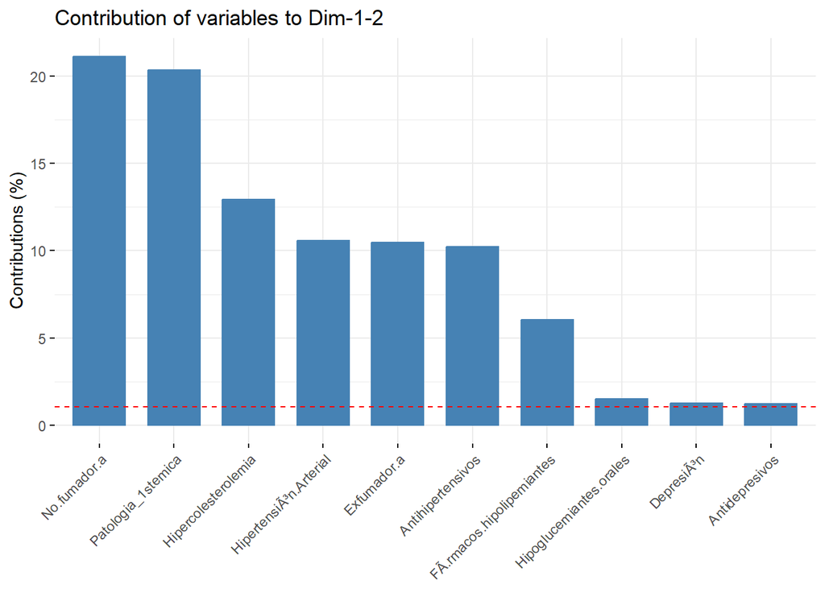

```r
plot_var_contrib
```

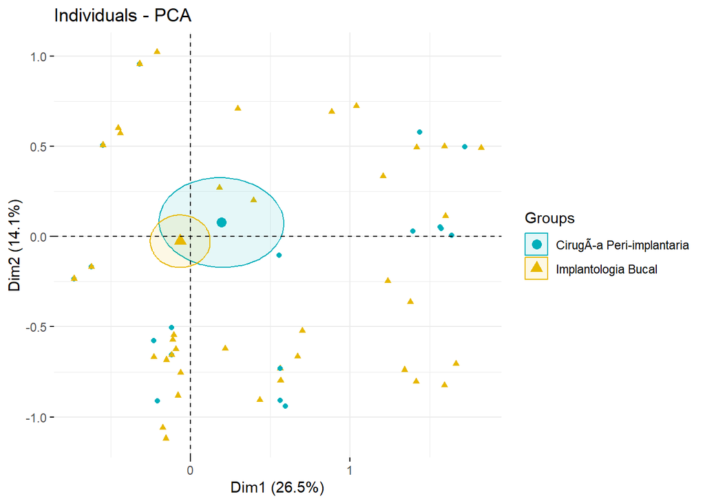

```r
plot_ind_pca_gender <- fviz_pca_ind(pca_result,
                                    label = "none",
                                    habillage = tipo_intervencion,
                                    palette = c("#00AFBB", "#E7B800", "#FC4E07"),
                                    addEllipses = TRUE,
                                    ellipse.type = "confidence",
                                    repel = TRUE)
plot_ind_pca_gender
```

probamos ahora quitando la variable Patologia_1stematica y Medicacion_Actual2 ya que esa infor ya nos la dan las distintas patlogías y medicaciones. Además, tb añadiremos probar a eliminamos las medicinas o enfermedades que apaerzcan menos de 3 veces. (2 o menos)

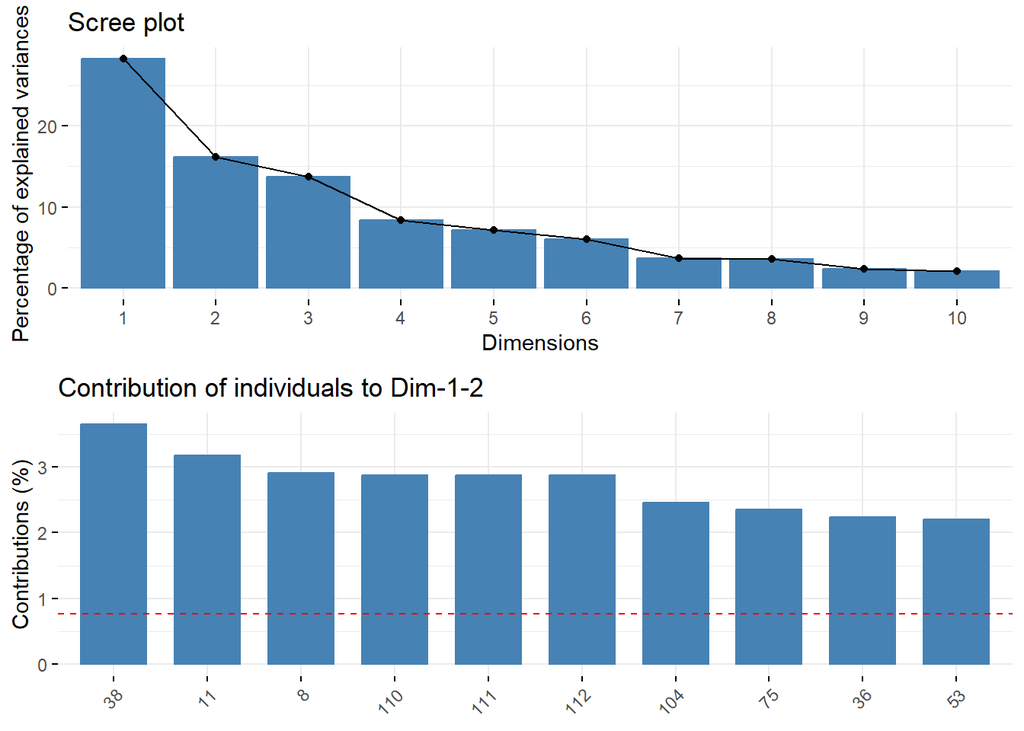

```r
dataPCA_comparativo <- select(dataPCA_comparativo, -Patologia_1stemica, -Medicacion_Actual2)

# Instala y carga el paquete dplyr si aún no lo has hecho
if (!require(dplyr)) {
  install.packages("dplyr")
}
library(dplyr)

# Suponiendo que tienes un DataFrame llamado dataPCA_comparativo

# Función para filtrar y eliminar variables con 1 dos veces o menos a partir de la cuarta columna
filtrar_variables <- function(data, threshold = 2) {

  # Contar las apariciones de 1 en cada columna a partir de la cuarta columna
  conteo <- data %>%
    select(4:ncol(data)) %>%
    summarise_all(sum)

  # Identificar columnas a eliminar
  columnas_eliminar <- names(conteo)[conteo <= threshold]

  # Eliminar las columnas del DataFrame original
  data_filtrado <- data %>%
    select(-one_of(columnas_eliminar))

  return(data_filtrado)
}

# Aplicar la función para filtrar variables a partir de la cuarta columna
dataPCA_comparativo_filtrado <- filtrar_variables(dataPCA_comparativo)


pca_result <- prcomp(dataPCA_comparativo_filtrado)

# Gráfico de la varianza explicada por cada componente principal
plot_eigenvalues <- fviz_eig(pca_result)

# Gráfico de las contribuciones de las variables a los ejes principales
plot_var_contrib <- fviz_contrib(pca_result, choice = "var", axes = 1:2, top = 10)

# Gráfico de las contribuciones de los individuos a los ejes principales
plot_ind_contrib <- fviz_contrib(pca_result, choice = "ind", axes = 1:2, top = 10)

# Organizar los gráficos en una cuadrícula
grid.arrange(plot_eigenvalues, plot_ind_contrib,
             ncol = 1)
```

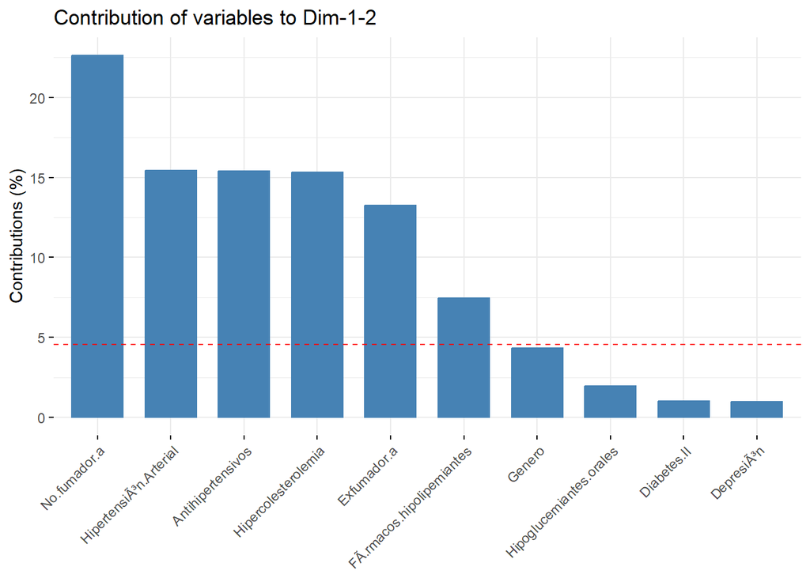

```r
plot_var_contrib
```

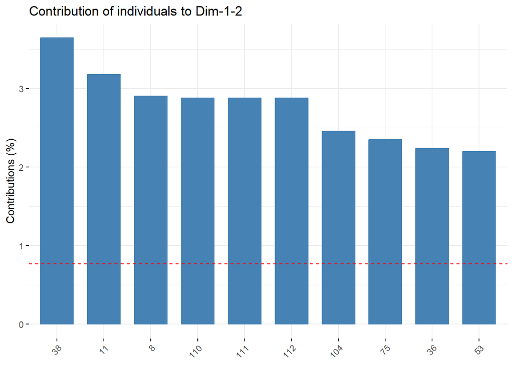

```r
plot_ind_contrib
```

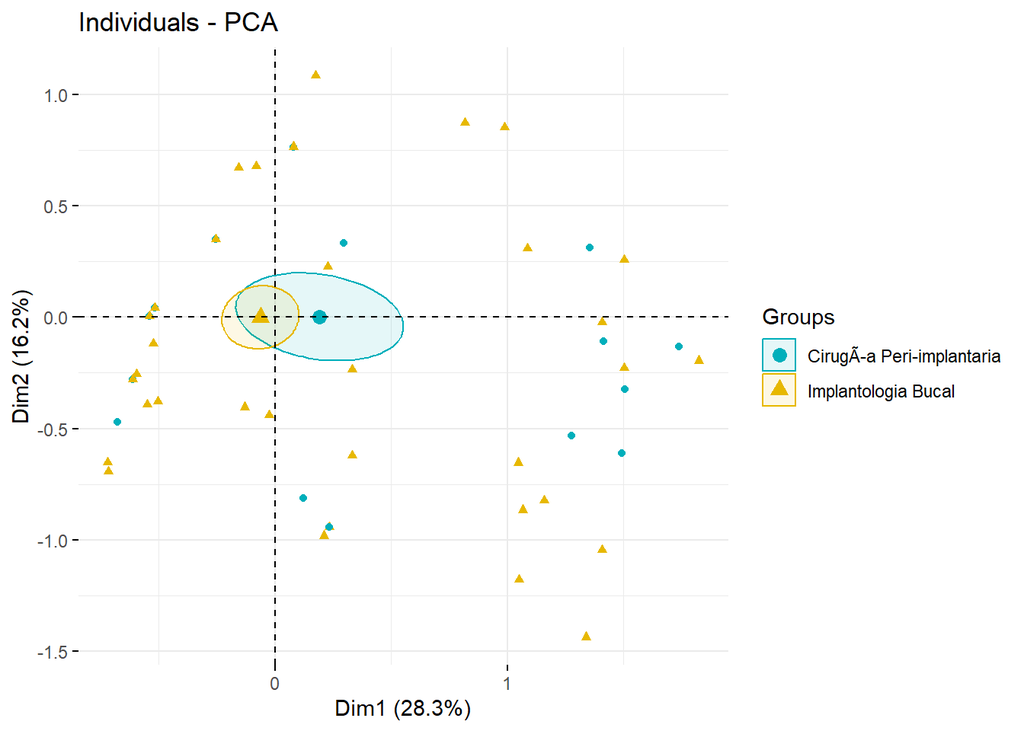

```r
plot_ind_pca_gender <- fviz_pca_ind(pca_result,
                                    label = "none",
                                    habillage = tipo_intervencion,
                                    palette = c("#00AFBB", "#E7B800", "#FC4E07"),
                                    addEllipses = TRUE,
                                    ellipse.type = "confidence",
                                    repel = TRUE)
plot_ind_pca_gender
```

##INTENTO REGLAS DE ASOCIACIÓN no se puede porq hay muy pocos unos

#AFC SOLO DE LOS DE PERIIMPLANTITS

Realizamos un AFC a partir solo de los de cirugía periimplantaria, para ver que categóricas influyen en los pacientes solo de periimplantarias.

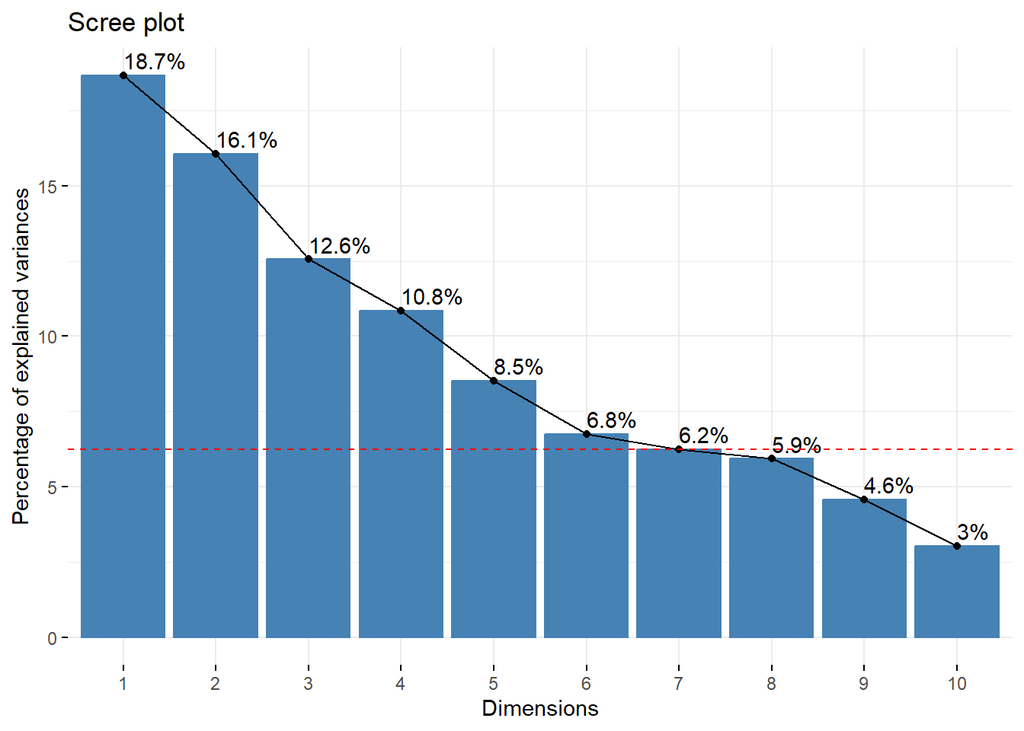

```r
datos_Periimplantaria_CAT <- dataCAT %>%
  filter(dataCAT$Tipo_De_Intervencion_Quirurgica == "CirugÃa Peri-implantaria")

res.mca2 <- MCA(datos_Periimplantaria_CAT, graph = FALSE, quali.sup = 1)
eig.val2 <- get_eigenvalue(res.mca2)
VPmedio2 = 100 * (1/nrow(eig.val2))
fviz_eig(res.mca2, addlabels = TRUE) + geom_hline(yintercept=VPmedio2, linetype=2, color="red")
```

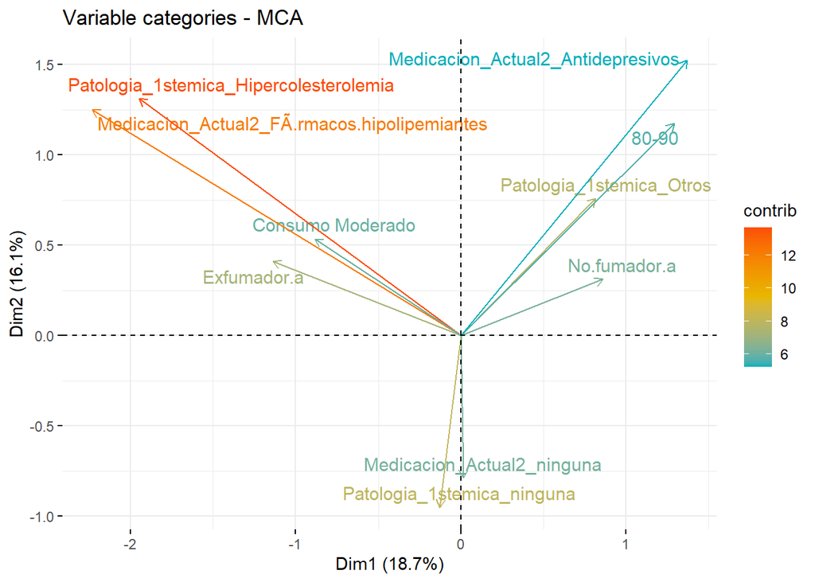

```r
plot_var_contrib_pca <- fviz_pca_var(res.mca2,
                                     select.var = list(contrib = 10), # Selecciona variables que contribuyen al menos un 10%
                                     col.var = "contrib", # Color de las variables basado en su contribución
                                     gradient.cols = c("#00AFBB", "#E7B800", "#FC4E07"), # Colores del gradiente
                                     repel = TRUE) # Evitar solapamiento de etiquetas

# Mostrar el gráfico
print(plot_var_contrib_pca)
```

#A PARTIR DE AQUÍ PCA POR SEPARADO

Comparamos que variables son las mas diferentes en los distintos pacientes.

```r
#head(datos_Implantologia_Bucal)
library(dplyr)

dataPCA <- select(dataPCA, -Patologia_1stemica, -Medicacion_Actual2)
datos_Periimplantaria <- dataPCA %>%
  filter(dataPCA$Tipo_De_Intervencion_Quirurgica == "CirugÃa Peri-implantaria")
datos_Periimplantaria_p <- datos_Periimplantaria %>%
  select_if(is.numeric)

datos_Implantologia_Bucal <- dataPCA %>%
  filter(dataPCA$Tipo_De_Intervencion_Quirurgica == "Implantologia Bucal")
datos_Implantologia_Bucal_p <- datos_Implantologia_Bucal %>%
  select_if(is.numeric)
```

Primero, creamos un subconjunto llamado *‘datos_Implantologia_Bucal’*, que contiene únicamente las filas de *‘data’* donde la variable *‘Tipo_De_Intervencion_Quirurgica’* es igual a *‘Implantologia Bucal’*.

Luego, creamos otro subconjunto llamado *‘datos_Periimplantaria’*, que contiene las filas de *‘data’* donde la variable *‘Tipo_De_Intervencion_Quirurgica’* es igual a *‘Cirugía Peri-implantaria’*.

## Limpieza

# PCA

En este análisis de PCA, exploraremos las características de los pacientes sometidos a **Implantología Bucal** y **Cirugía Periimplantaria** en odontología. El PCA nos permitirá identificar patrones y relaciones entre las variables, proporcionando conociiento sobre las diferencias y similitudes entre ambas intervenciones quirúrgicas.

## Implantologia

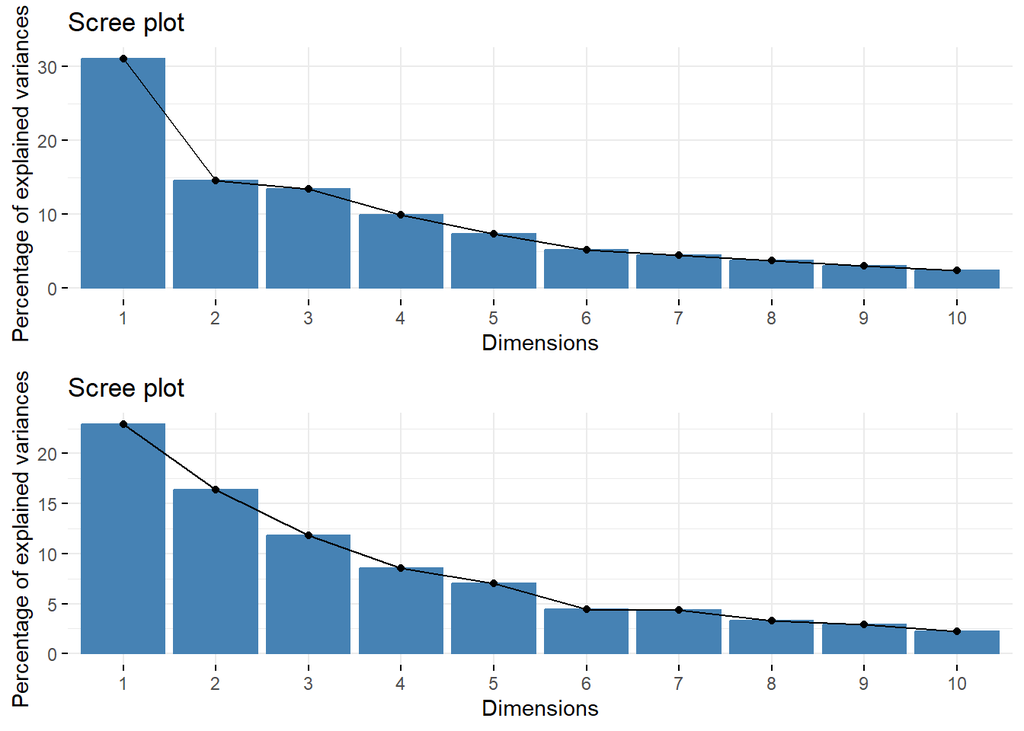

```r
library(factoextra)
library(cluster)
library(gridExtra)

pca_result1 <- prcomp(datos_Periimplantaria_p)

# Gráfico de la varianza explicada por cada componente principal
plot_eigenvalues1 <- fviz_eig(pca_result1)

# Gráfico de las contribuciones de las variables a los ejes principales
plot_var_contrib1 <- fviz_contrib(pca_result1, choice = "var", axes = 1:2, top = 10)





pca_result2 <- prcomp(datos_Implantologia_Bucal_p)

# Gráfico de la varianza explicada por cada componente principal
plot_eigenvalues2 <- fviz_eig(pca_result2)

# Gráfico de las contribuciones de las variables a los ejes principales
plot_var_contrib2 <- fviz_contrib(pca_result2, choice = "var", axes = 1:2, top = 10)

# Organizar los gráficos en una cuadrícula
grid.arrange(plot_eigenvalues1, plot_eigenvalues2,
             ncol = 1)
```

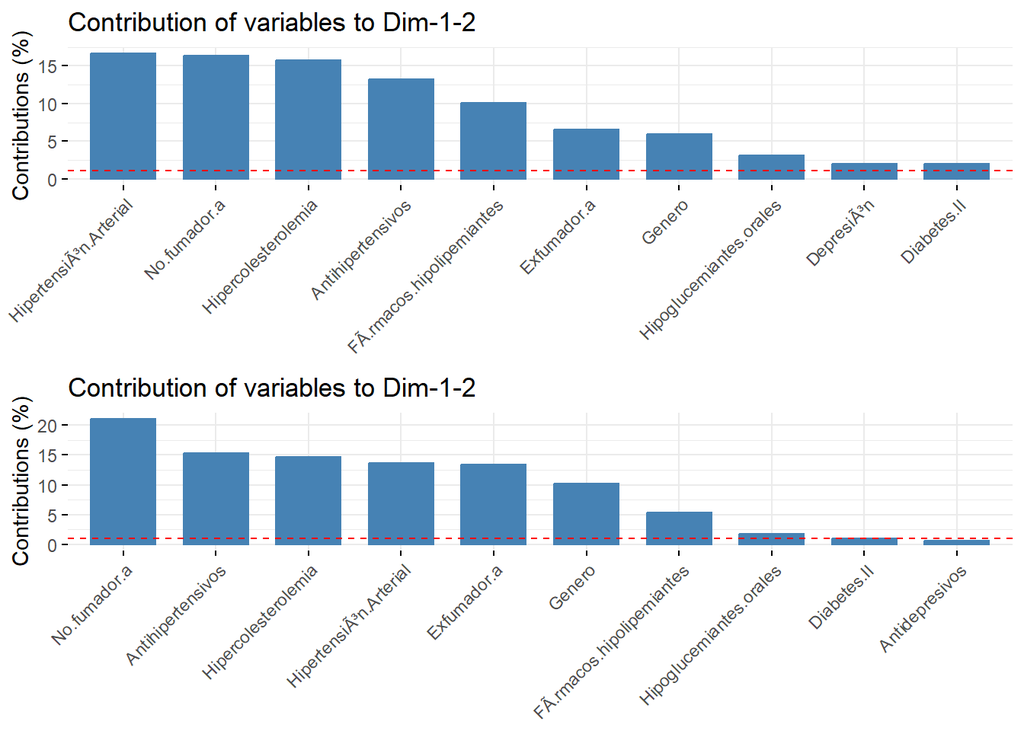

```r
grid.arrange(plot_var_contrib1, plot_var_contrib2,
             ncol = 1)
```